# Question

The continuous random variable $X$ follows the distribution shown by the density curve and spinner below. It has a mean of $\mu_{X}=48.37$ and standard deviation of $\sigma_{X}=3.42$.

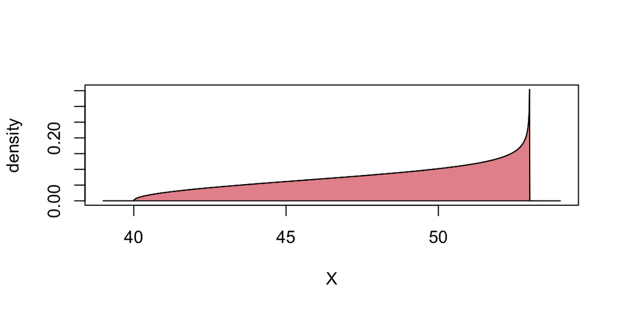

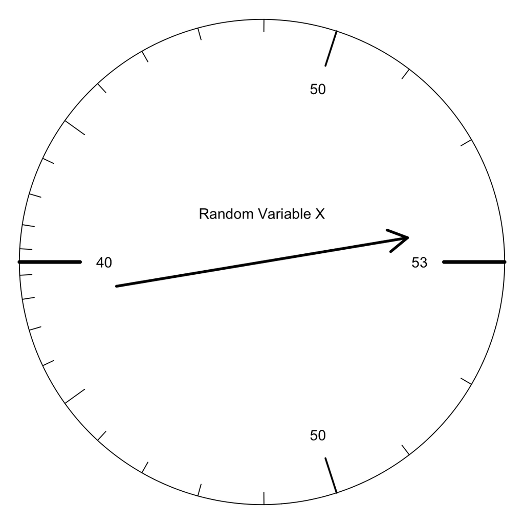

That spinner ($X$) will be fairly spun 285 times, and the **sample mean** of the spins will be recorded. Determine the probability that the random sample mean is more than 48.54.
$$P\left(\bar{X}>48.54\right) ~=~ \,?$$

(Even though single spins are **not** normally distributed, the random means will be normally distributed. See [central limit theorem](https://en.wikipedia.org/wiki/Central_limit_theorem).)

# Solution

[video](https://vimeo.com/531941288)

We use the central limit formulas for a random mean.
$$\mu_{\bar{X}} = \mu_{X} = 48.37$$
$$\sigma_{\bar{X}} = \frac{\sigma_{X}}{\sqrt{n}} =
\frac{3.42}{\sqrt{285}} = 0.2025833$$
So, we think the random mean is normally distributed with a mean of 48.37 and a standard deviation of 0.2025833.
$$\bar{X} \sim
N(48.37,\,0.2025833)$$

Calculate a $z$-score for the boundary.
$$z = \frac{48.54-48.37}{0.2025833}
= 0.8391609$$

You can round that to $z=0.83$ or $z=0.84$. Any of the following probabilities will get credit.
$$P(Z >
0.8391609) = 0.2006895$$
$$P(Z >
0.83) = 0.2033$$
$$P(Z > 0.84) =
0.2005$$

To get the probability, you can use a spreadsheet. Either will work:

- `=1-NORMDIST(0.8391609,0,1,TRUE)`
- `=1-NORMDIST(48.54,48.37,0.2025833,TRUE)`

Let’s draw a sketch.

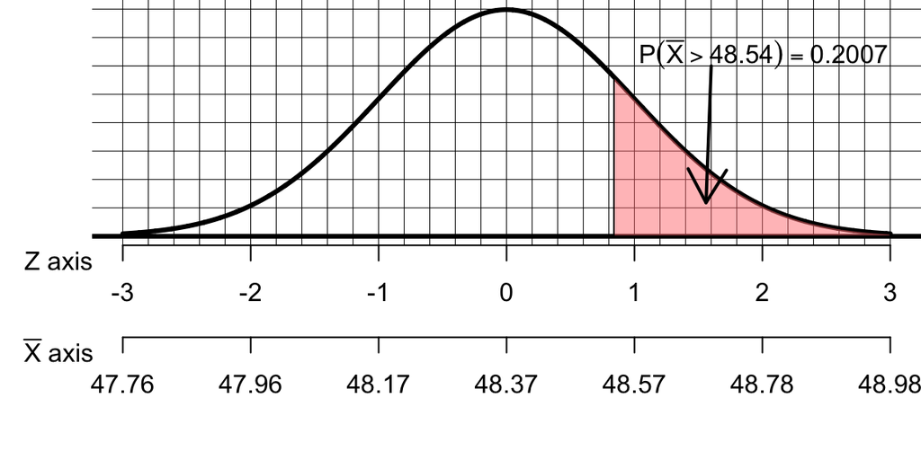

# Meta-information

extype: num exsolution: 0.2006895 exname: prob ave more extol: 0.01